# Part II - (Prosper Loan Presentation)

## by (Rita Adesina)

## Investigation Overview

In exploring this data, I was interested in how the perosnal features of the individuals relates with the financial features.

I was able to draw that being employed gave the highest loan amount, and that most people that actually got loans were people who were employed. Although other categories got loans too, but not as high in amount as those who were employed. I was able to see the preferred Loan term for the applicants. T was able to see how the borrower's rate relates with being a house owner. I also noticed that people who took high aamount of loan were able to complete them, while others are still servicing term within their loan term. Just very few people defaulted amoongst those who took a high amouunt. I did not make any modification to the dataset, I used all the figuresasthey were to draw my key insights.

## Dataset Overview

The data contains various features of individuals who took a loan from a company. The data had 81 columns and over a 100,000 rows. The columns had perosnal, and financial features of borrowers. Some perosnal features included, their occupation, employment status, location, property owner, loan status, propser rating and score among others Some financial features included their income range, stated monthly repayment, estimated return and loss, Borrower's rate and APR I got this data from my udacity classrom.

## Analyzing Employment Status vs Loan Amount.

. My first insight from this dataset is that employed people were more, and that amongst those who applied for a lot of money, the emploed people got more money.

. It is important to note that other employment status got loan too, but none as high as the employed people, coming close was the self-employed and least was the part-time not the retirees as i might have presumed.

This is bearing in mind that the count of retirees is lower compared to part time.

This can be explained by various assumption, one being that the part time workers are really young people barely starting life, while the retirees are more seasoned, thus might have thier funds locked in various investments, or have cushion to get them a higher loan amount.

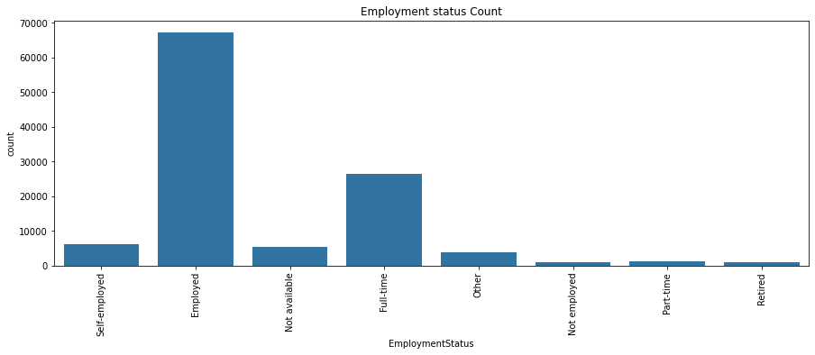

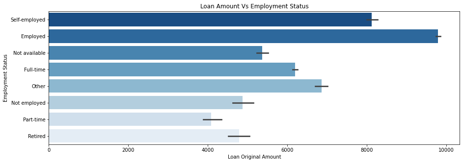

## Dissecting Preferred Loan Term along Employment Status Categories.

Another insight for me was seeing the preferred Loan term amoong various employment status. All the status prefer the 36 months term as opposed to the 12 or 60 months. And also only considerable few subscribed to the 12 months plan, and that is only visible among the employed status.

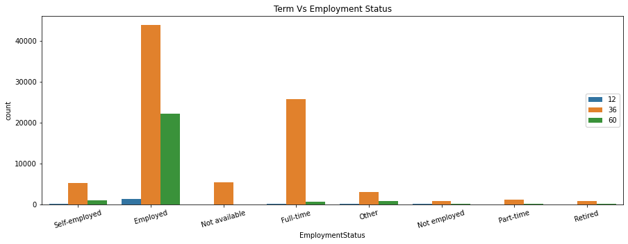

## Understanding the relationship between home owners and borrower's rate.

It is pertinent to note that the distribution between home owners in this dataset is almsot equal, with homeowner being the most by a very small margin. The analysis showed that home owners had a lesser borrower's rate from 2006, compared to non-home owners and this could be because they had used their home for collateral thus limiting the final cost involved in securing a loan.

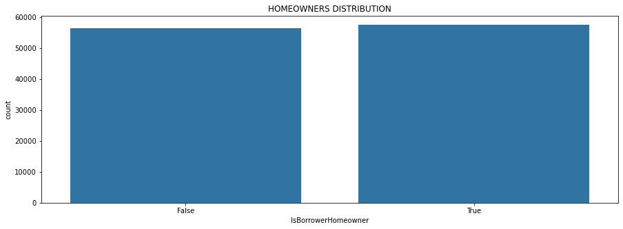

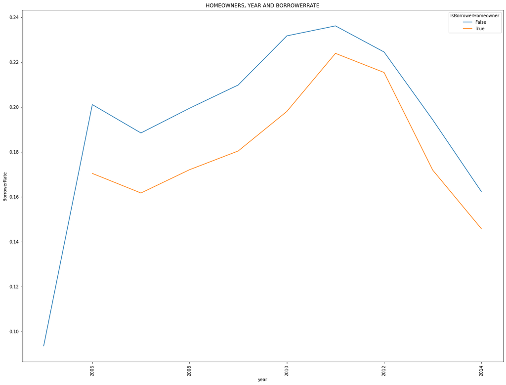